# Concrete

2025-10-20

## Contexto y Introduccion

📚 CONTEXTO BREVE

El concreto es un material de construcción crítico. Su resistencia a la compresión determina si una estructura es segura y durable. Este dataset contiene 1,030 muestras de concreto con diferentes composiciones y edades, con el objetivo de predecir su resistencia final basado en sus ingredientes.

📊 VARIABLES

Variable Respuesta: Compressive Strength (Y) - Resistencia a la compresión en MPa (megapascales)

Variables Predictoras :

Cement (X₁) - Cantidad de cemento en kg/m³

Blast Furnace Slag (X₂) - Cantidad de escoria en kg/m³

Fly Ash (X₃) - Cantidad de ceniza volante en kg/m³

Water (X₄) - Cantidad de agua en kg/m³

Superplasticizer (X₅) - Cantidad de aditivo en kg/m³

Coarse Aggregate (X₆) - Cantidad de grava en kg/m³

Fine Aggregate (X₇) - Cantidad de arena en kg/m³

Age (X₈) - Edad del concreto en días

### Clasificacion de las variables

```r
tabla_variables <- data.frame(
  Variable = c(
    "Cement",
    "Blast Furnace Slag",
    "Fly Ash",
    "Water",
    "Superplasticizer",
    "Coarse Aggregate",
    "Fine Aggregate",
    "Age",
    "Compressive Strength"
  ),
  Tipo = c(
    rep("Numérica continua", 7),
    "Numérica discreta",
    "Numérica continua"
  ),
  `Escala de Medición` = c(
    rep("Razón", 8),
    "Razón"
  ),
  check.names = FALSE
)

# Crear tabla formateada para bookdown
kable(tabla_variables,
      caption = "Descripción de Variables del Dataset Concrete Compressive Strength",
      booktabs = TRUE,
      longtable = TRUE) %>%
  kable_styling(bootstrap_options = c("striped", "hover", "condensed"),
                latex_options = c("striped", "hold_position"),
                full_width = FALSE,
                font_size = 10) %>%
  column_spec(1, bold = TRUE, width = "3cm") %>%
  column_spec(2, width = "3cm") %>%
  column_spec(3, width = "2.5cm")
```

Descripción de Variables del Dataset Concrete Compressive Strength

| Variable | Tipo | Escala de Medición |
| --- | --- | --- |
| Cement | Numérica continua | Razón |
| Blast Furnace Slag | Numérica continua | Razón |
| Fly Ash | Numérica continua | Razón |
| Water | Numérica continua | Razón |
| Superplasticizer | Numérica continua | Razón |
| Coarse Aggregate | Numérica continua | Razón |
| Fine Aggregate | Numérica continua | Razón |
| Age | Numérica discreta | Razón |
| Compressive Strength | Numérica continua | Razón |

## Importacion del dataset y exploracion incial

### Caracteristicas del dataset

```r
data(Concrete)
head(Concrete)
```

```
##   Cement Blast Furnace Slag Fly Ash Water Superplasticizer Coarse Aggregate
## 1  540.0                0.0       0   162              2.5           1040.0
## 2  540.0                0.0       0   162              2.5           1055.0
## 3  332.5              142.5       0   228              0.0            932.0
## 4  332.5              142.5       0   228              0.0            932.0
## 5  198.6              132.4       0   192              0.0            978.4
## 6  266.0              114.0       0   228              0.0            932.0
##   Fine Aggregate Age Concrete Compressive Strength
## 1          676.0  28                         79.99
## 2          676.0  28                         61.89
## 3          594.0 270                         40.27
## 4          594.0 365                         41.05
## 5          825.5 360                         44.30
## 6          670.0  90                         47.03
```

```r
dim(Concrete)
```

```
## [1] 1030    9
```

```r
colnames(Concrete)
```

```
## [1] "Cement"                        "Blast Furnace Slag"
## [3] "Fly Ash"                       "Water"
## [5] "Superplasticizer"              "Coarse Aggregate"
## [7] "Fine Aggregate"                "Age"
## [9] "Concrete Compressive Strength"
```

```r
str(Concrete)
```

```
## 'data.frame':    1030 obs. of  9 variables:
##  $ Cement                       : num  540 540 332 332 199 ...
##  $ Blast Furnace Slag           : num  0 0 142 142 132 ...
##  $ Fly Ash                      : num  0 0 0 0 0 0 0 0 0 0 ...
##  $ Water                        : num  162 162 228 228 192 228 228 228 228 228 ...
##  $ Superplasticizer             : num  2.5 2.5 0 0 0 0 0 0 0 0 ...
##  $ Coarse Aggregate             : num  1040 1055 932 932 978 ...
##  $ Fine Aggregate               : num  676 676 594 594 826 ...
##  $ Age                          : int  28 28 270 365 360 90 365 28 28 28 ...
##  $ Concrete Compressive Strength: num  80 61.9 40.3 41 44.3 ...
```

### Revision de valores faltantes

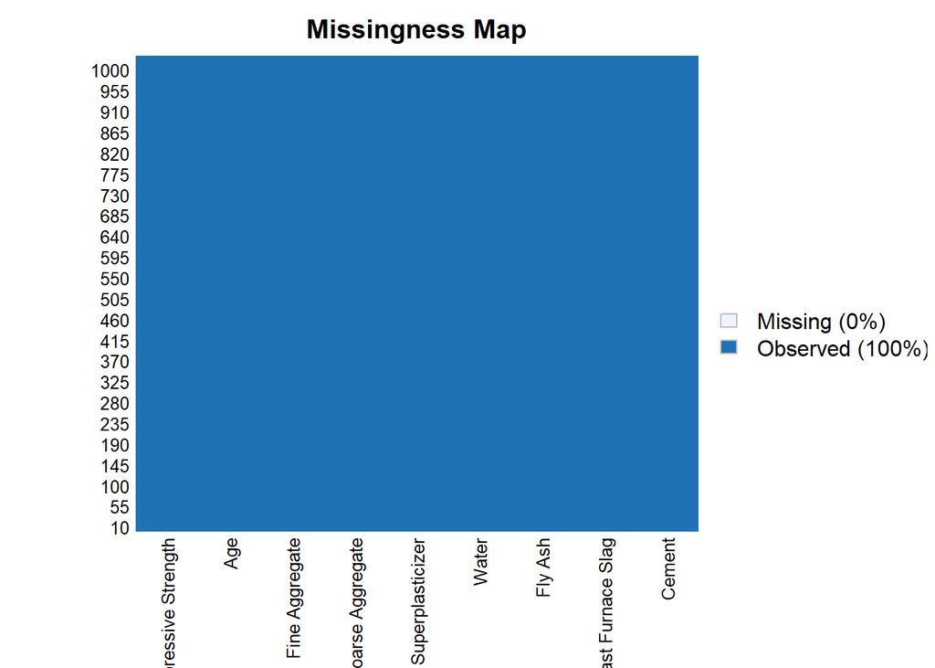

```r
missmap(Concrete)
```

El dataset Concrete Compressive Strength contiene 1,030 observaciones de muestras de concreto obtenidas de experimentos de laboratorio, sin valores faltantes. Cuenta con 9 variables en total: 8 predictoras (7 numéricas continuas y 1 numérica discreta) y 1 variable respuesta numérica continua. Todas las variables tienen escala de medición de razón. Se trata de un dataset limpio y de alta calidad, con datos de origen controlado , siendo probablemente un prospecto óptimo para análisis de regresión lineal sin necesidad de transformaciones.

## Analisis Univariante

### Compressive Strength

```r
Concrete %>%
  summarise(
    n = length(Concrete[[9]]),
    media = mean(Concrete[[9]]),
    ds = sd(Concrete[[9]]),
    mediana = median(Concrete[[9]]),
    minimo = min(Concrete[[9]]),
    maximo = max(Concrete[[9]]),
    Q1 = quantile(Concrete[[9]], 0.25),
    Q3 = quantile(Concrete[[9]], 0.75),
    IQR = IQR(Concrete[[9]])
  )
```

```
##      n    media       ds mediana minimo maximo    Q1     Q3    IQR
## 1 1030 35.81796 16.70574  34.445   2.33   82.6 23.71 46.135 22.425
```

La variable Compressive Strength fue analizada a partir de 1.030 observaciones. Se obtuvo una resistencia promedio de aproximadamente 35,82 MPa (DS = 16,71 MPa), donde el 50% de las muestras presentan resistencias por debajo de 34,45 MPa. El mínimo registrado fue de 2,33 MPa, lo que indica mezclas de concreto muy jóvenes (posiblemente evaluadas a 1 día de curado) o con proporciones poco óptimas de ingredientes. Por su parte, el máximo alcanzó los 82,6 MPa, lo cual refleja mezclas de alta resistencia con composiciones especiales, mayor contenido de cemento, uso de superplastificantes y tiempos de curado prolongados (hasta 365 días según el dataset). El rango intercuartílico (IQR = 22,43 MPa) muestra una variabilidad considerable, con el primer cuartil (Q1) en 23,71 MPa y el tercer cuartil (Q3) en 46,14 MPa. Esta dispersión confirma que la resistencia del concreto está fuertemente influenciada por la combinación de factores como la dosificación de cemento, la presencia de materiales suplementarios (escoria y ceniza volante), la relación agua-cemento y, especialmente, la edad de curado.

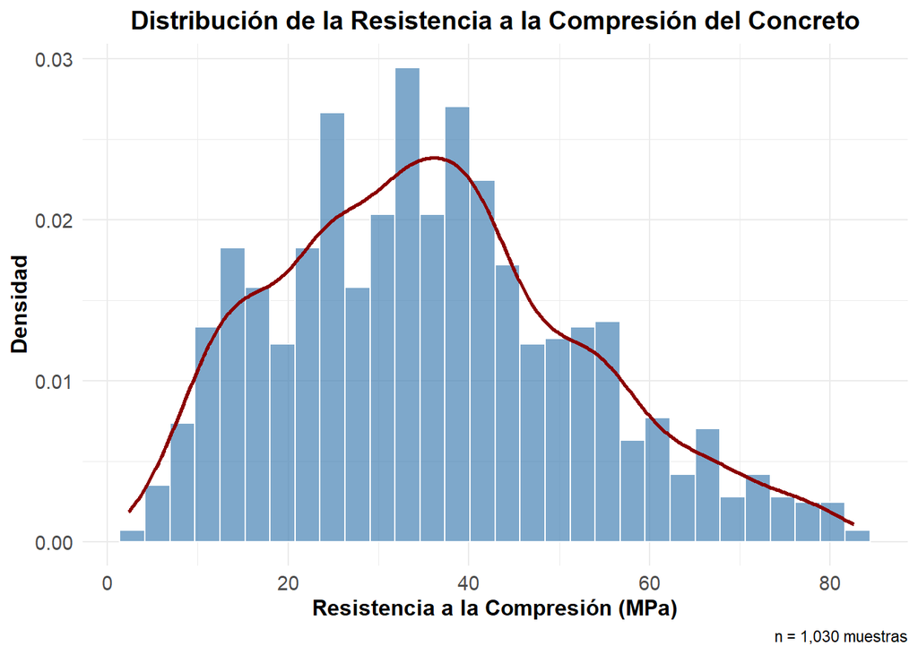

```r
# Histograma con curva de densidad
ggplot(Concrete, aes(x = Concrete[[9]])) +
  geom_histogram(aes(y = after_stat(density)),
                 fill = "steelblue", color = "white", bins = 30, alpha = 0.7) +
  geom_density(color = "darkred", linewidth = 1) +
  labs(
    title = "Distribución de la Resistencia a la Compresión del Concreto",
    x = "Resistencia a la Compresión (MPa)",
    y = "Densidad",
    caption = "n = 1,030 muestras"
  ) +
  theme_minimal() +
  theme(
    plot.title = element_text(hjust = 0.5, face = "bold", size = 14),
    axis.text = element_text(size = 11),
    axis.title = element_text(face = "bold", size = 12)
  )
```

Se puede ver en el grafico la heterogenidad de los datos sin contar esa leve sesgo a la derecha lo que significa que las otras variables no deben estar influyendo de manera drastica en los estadísticos como la media y la desviación estándar

### Cement

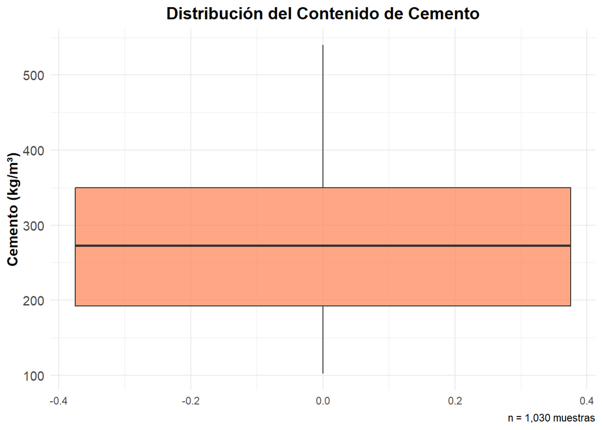

```r
ggplot(Concrete, aes(y = Cement)) +
  geom_boxplot(fill = "coral", alpha = 0.7, outlier.color = "red", outlier.size = 2) +
  labs(
    title = "Distribución del Contenido de Cemento",
    y = "Cemento (kg/m³)",
    caption = "n = 1,030 muestras"
  ) +
  theme_minimal() +
  theme(
    plot.title = element_text(hjust = 0.5, face = "bold", size = 14),
    axis.text.y = element_text(size = 11),
    axis.title.y = element_text(face = "bold", size = 12)
  )
```

```r
Concrete %>%
  summarise(
    n = length(Cement),
    media = mean(Cement),
    ds = sd(Cement),
    CV = (sd(Cement) / mean(Cement)) * 100,
    mediana = median(Cement),
    minimo = min(Cement),
    maximo = max(Cement),
    Q1 = quantile(Cement, 0.25),
    Q3 = quantile(Cement, 0.75),
    IQR = IQR(Cement)

  )
```

```
##      n    media       ds       CV mediana minimo maximo      Q1  Q3     IQR
## 1 1030 281.1679 104.5064 37.16867   272.9    102    540 192.375 350 157.625
```

### Blast Furnace Slag

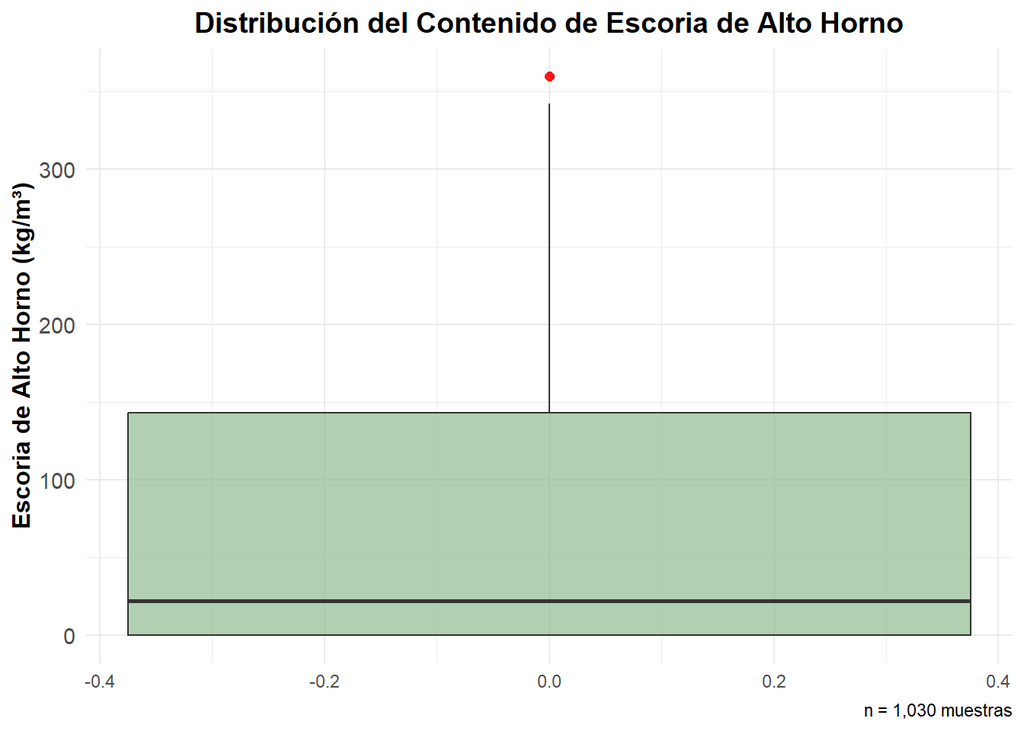

```r
ggplot(Concrete, aes(y = `Blast Furnace Slag`)) +
  geom_boxplot(fill = "darkseagreen", alpha = 0.7, outlier.color = "red", outlier.size = 2) +
  labs(
    title = "Distribución del Contenido de Escoria de Alto Horno",
    y = "Escoria de Alto Horno (kg/m³)",
    caption = "n = 1,030 muestras"
  ) +
  theme_minimal() +
  theme(
    plot.title = element_text(hjust = 0.5, face = "bold", size = 14),
    axis.text.y = element_text(size = 11),
    axis.title.y = element_text(face = "bold", size = 12)
  )
```

```r
Concrete %>%
  summarise(
    n = length(`Blast Furnace Slag`),
    media = mean(`Blast Furnace Slag`),
    ds = sd(`Blast Furnace Slag`),
    CV = (sd(`Blast Furnace Slag`) / mean(`Blast Furnace Slag`)) * 100,
    mediana = median(`Blast Furnace Slag`),
    minimo = min(`Blast Furnace Slag`),
    maximo = max(`Blast Furnace Slag`),
    Q1 = quantile(`Blast Furnace Slag`, 0.25),
    Q3 = quantile(`Blast Furnace Slag`, 0.75),
    IQR = IQR(`Blast Furnace Slag`)
  )
```

```
##      n    media       ds       CV mediana minimo maximo Q1     Q3    IQR
## 1 1030 73.89583 86.27934 116.7581      22      0  359.4  0 142.95 142.95
```

La variable Blast Furnace Slag presenta una media de 73,90 kg/m³ (DS = 86,28 kg/m³) con un coeficiente de variación del 116,76%, indicando una variabilidad extremadamente alta. La mediana de 22 kg/m³ es considerablemente menor que la media, revelando una marcada asimetría positiva. El rango oscila entre 0 kg/m³ (mezclas sin escoria) y 359,4 kg/m³ (mezclas con alto contenido de este material suplementario). El boxplot muestra que más del 50% de las muestras contienen cantidades bajas de escoria (Q1 = 0; Q3 = 142,95 kg/m³), con un valor atípico extremo alrededor de 360 kg/m³. Esta alta variabilidad refleja que la escoria es un ingrediente opcional utilizado selectivamente para mejorar propiedades específicas del concreto o reducir costos.

### Fly Ash

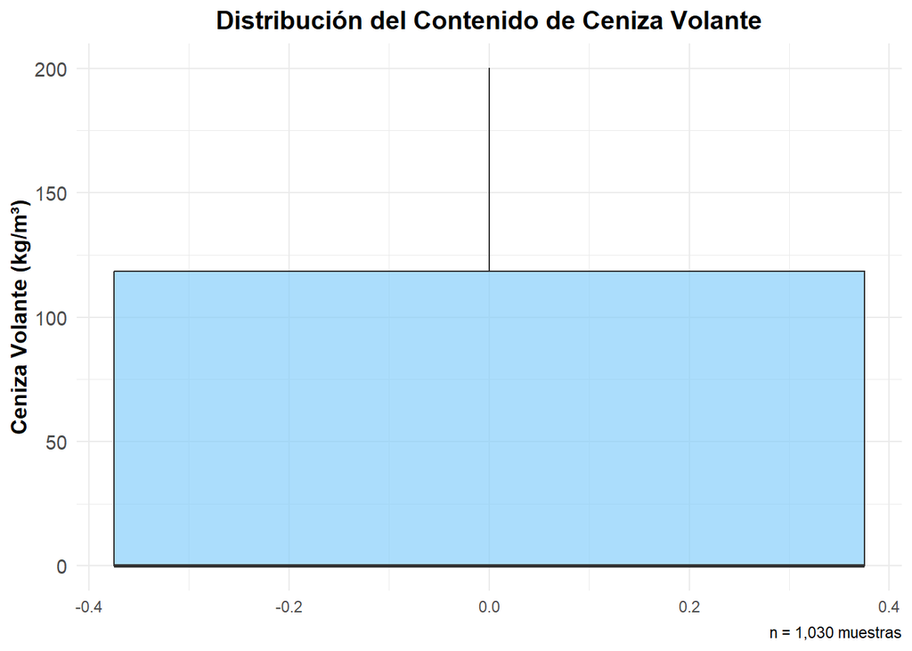

```r
ggplot(Concrete, aes(y = `Fly Ash`)) +
  geom_boxplot(fill = "lightskyblue", alpha = 0.7, outlier.color = "red", outlier.size = 2) +
  labs(
    title = "Distribución del Contenido de Ceniza Volante",
    y = "Ceniza Volante (kg/m³)",
    caption = "n = 1,030 muestras"
  ) +
  theme_minimal() +
  theme(
    plot.title = element_text(hjust = 0.5, face = "bold", size = 14),
    axis.text.y = element_text(size = 11),
    axis.title.y = element_text(face = "bold", size = 12)
  )
```

```r
Concrete %>%
  summarise(
    n = length(`Fly Ash`),
    media = mean(`Fly Ash`),
    ds = sd(`Fly Ash`),
    CV = (sd(`Fly Ash`) / mean(`Fly Ash`)) * 100,
    mediana = median(`Fly Ash`),
    minimo = min(`Fly Ash`),
    maximo = max(`Fly Ash`),
    Q1 = quantile(`Fly Ash`, 0.25),
    Q3 = quantile(`Fly Ash`, 0.75),
    IQR = IQR(`Fly Ash`)
  )
```

```
##      n    media     ds      CV mediana minimo maximo Q1    Q3   IQR
## 1 1030 54.18835 63.997 118.101       0      0  200.1  0 118.3 118.3
```

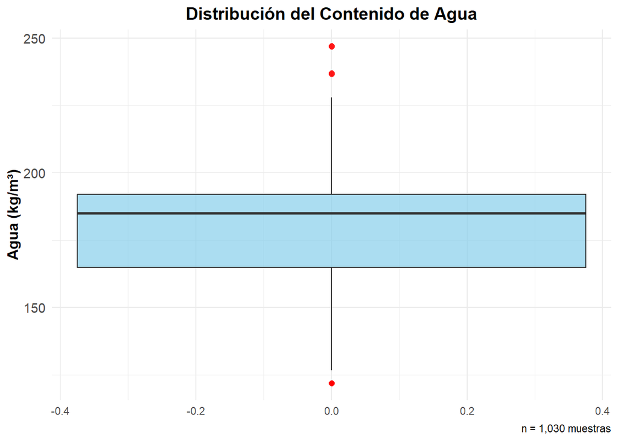

```r
ggplot(Concrete, aes(y = Water)) +
  geom_boxplot(fill = "skyblue", alpha = 0.7, outlier.color = "red", outlier.size = 2) +
  labs(
    title = "Distribución del Contenido de Agua",
    y = "Agua (kg/m³)",
    caption = "n = 1,030 muestras"
  ) +
  theme_minimal() +
  theme(
    plot.title = element_text(hjust = 0.5, face = "bold", size = 14),
    axis.text.y = element_text(size = 11),
    axis.title.y = element_text(face = "bold", size = 12)
  )
```

```r
Concrete %>%
  summarise(
    n = length(Water),
    media = mean(Water),
    ds = sd(Water),
    CV = (sd(Water) / mean(Water)) * 100,
    mediana = median(Water),
    minimo = min(Water),
    maximo = max(Water),
    Q1 = quantile(Water, 0.25),
    Q3 = quantile(Water, 0.75),
    IQR = IQR(Water)
  )
```

```
##      n    media       ds       CV mediana minimo maximo    Q1  Q3  IQR
## 1 1030 181.5673 21.35422 11.76105     185  121.8    247 164.9 192 27.1
```

La variable Water presenta una media de 181,57 kg/m³ (DS = 21,35 kg/m³) con un coeficiente de variación del 11,76%, indicando baja variabilidad en comparación con otras variables. La mediana de 185 kg/m³ es cercana a la media, sugiriendo una distribución relativamente simétrica. El rango oscila entre 121,8 kg/m³ y 247 kg/m³, con un IQR reducido de 27,1 kg/m³ (Q1 = 164,9; Q3 = 192). El boxplot muestra algunos valores atípicos tanto superiores como inferiores, representando mezclas con relaciones agua-cemento extremas. Esta baja variabilidad refleja que el contenido de agua es un parámetro más controlado en el diseño de mezclas, ya que la relación agua-cemento es crítica para determinar la trabajabilidad y resistencia del concreto.

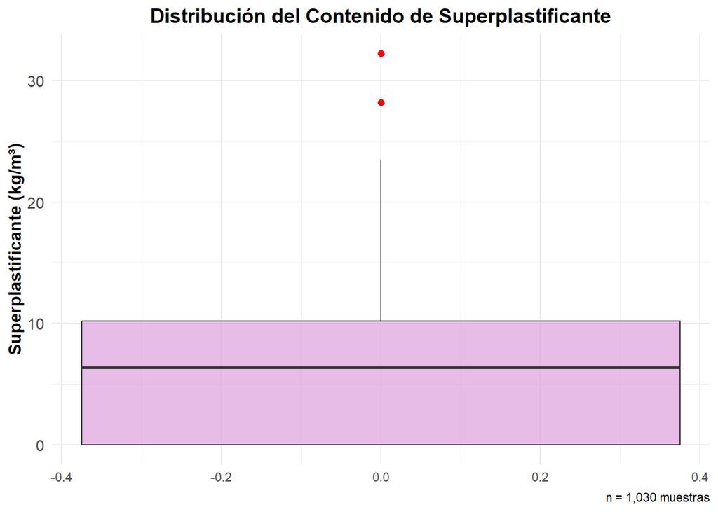

```r
ggplot(Concrete, aes(y = Superplasticizer)) +
  geom_boxplot(fill = "plum", alpha = 0.7, outlier.color = "red", outlier.size = 2) +
  labs(
    title = "Distribución del Contenido de Superplastificante",
    y = "Superplastificante (kg/m³)",
    caption = "n = 1,030 muestras"
  ) +
  theme_minimal() +
  theme(
    plot.title = element_text(hjust = 0.5, face = "bold", size = 14),
    axis.text.y = element_text(size = 11),
    axis.title.y = element_text(face = "bold", size = 12)
  )
```

```r
Concrete %>%
  summarise(
    n = length(Superplasticizer),
    media = mean(Superplasticizer),
    ds = sd(Superplasticizer),
    CV = (sd(Superplasticizer) / mean(Superplasticizer)) * 100,
    mediana = median(Superplasticizer),
    minimo = min(Superplasticizer),
    maximo = max(Superplasticizer),
    Q1 = quantile(Superplasticizer, 0.25),
    Q3 = quantile(Superplasticizer, 0.75),
    IQR = IQR(Superplasticizer)
  )
```

```
##      n   media       ds       CV mediana minimo maximo Q1   Q3  IQR
## 1 1030 6.20466 5.973841 96.27991     6.4      0   32.2  0 10.2 10.2
```

La variable Superplasticizer presenta una media de 6,20 kg/m³ (DS = 5,97 kg/m³) con un coeficiente de variación del 96,28%, indicando una variabilidad extremadamente alta. La mediana de 6,4 kg/m³ es cercana a la media, pero el mínimo de 0 kg/m³ revela que muchas mezclas no contienen este aditivo. El rango oscila entre 0 y 32,2 kg/m³, con un IQR de 10,2 kg/m³ (Q1 = 0; Q3 = 10,2). El boxplot muestra valores atípicos superiores alrededor de 28-32 kg/m³, representando mezclas de alto desempeño que requieren mayor fluidez. Esta distribución indica que el superplastificante es un aditivo químico opcional utilizado principalmente para mejorar la trabajabilidad del concreto sin aumentar el contenido de agua, siendo más común en mezclas de alta resistencia.

### Coarse Aggregate

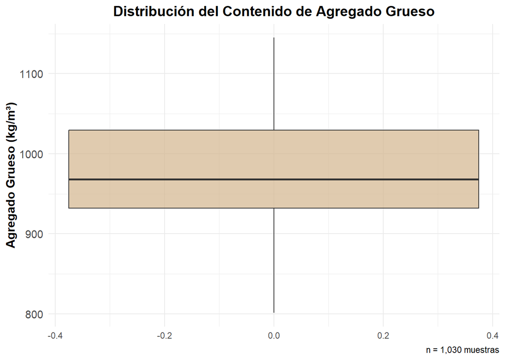

```r
ggplot(Concrete, aes(y = `Coarse Aggregate`)) +
  geom_boxplot(fill = "tan", alpha = 0.7, outlier.color = "red", outlier.size = 2) +
  labs(
    title = "Distribución del Contenido de Agregado Grueso",
    y = "Agregado Grueso (kg/m³)",
    caption = "n = 1,030 muestras"
  ) +
  theme_minimal() +
  theme(
    plot.title = element_text(hjust = 0.5, face = "bold", size = 14),
    axis.text.y = element_text(size = 11),
    axis.title.y = element_text(face = "bold", size = 12)
  )
```

```r
Concrete %>%
  summarise(
    n = length(`Coarse Aggregate`),
    media = mean(`Coarse Aggregate`),
    ds = sd(`Coarse Aggregate`),
    CV = (sd(`Coarse Aggregate`) / mean(`Coarse Aggregate`)) * 100,
    mediana = median(`Coarse Aggregate`),
    minimo = min(`Coarse Aggregate`),
    maximo = max(`Coarse Aggregate`),
    Q1 = quantile(`Coarse Aggregate`, 0.25),
    Q3 = quantile(`Coarse Aggregate`, 0.75),
    IQR = IQR(`Coarse Aggregate`)
  )
```

```
##      n    media       ds       CV mediana minimo maximo  Q1     Q3  IQR
## 1 1030 972.9189 77.75395 7.991822     968    801   1145 932 1029.4 97.4
```

La variable Coarse Aggregate presenta una media de 972,92 kg/m³ (DS = 77,75 kg/m³) con un coeficiente de variación del 7,99%, indicando muy baja variabilidad. La mediana de 968 kg/m³ es prácticamente igual a la media, confirmando una distribución simétrica. El rango oscila entre 801 y 1145 kg/m³, con un IQR muy reducido de 97,4 kg/m³ (Q1 = 932; Q3 = 1029,4). El boxplot muestra ausencia de valores atípicos y una distribución muy compacta. Esta baja variabilidad refleja que el agregado grueso (grava) es un componente estructural esencial presente en cantidades relativamente constantes en todas las mezclas de concreto, representando típicamente el mayor volumen dentro de la composición y siendo crucial para la integridad estructural del material.

### Fine Aggregate

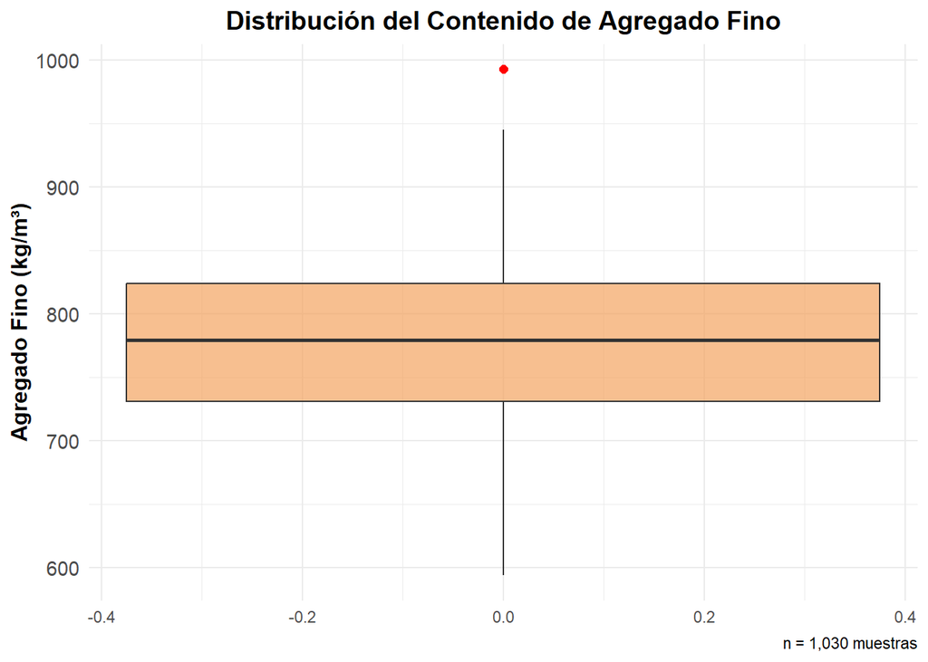

```r
ggplot(Concrete, aes(y = `Fine Aggregate`)) +
  geom_boxplot(fill = "sandybrown", alpha = 0.7, outlier.color = "red", outlier.size = 2) +
  labs(
    title = "Distribución del Contenido de Agregado Fino",
    y = "Agregado Fino (kg/m³)",
    caption = "n = 1,030 muestras"
  ) +
  theme_minimal() +
  theme(
    plot.title = element_text(hjust = 0.5, face = "bold", size = 14),
    axis.text.y = element_text(size = 11),
    axis.title.y = element_text(face = "bold", size = 12)
  )
```

```r
Concrete %>%
  summarise(
    n = length(`Fine Aggregate`),
    media = mean(`Fine Aggregate`),
    ds = sd(`Fine Aggregate`),
    CV = (sd(`Fine Aggregate`) / mean(`Fine Aggregate`)) * 100,
    mediana = median(`Fine Aggregate`),
    minimo = min(`Fine Aggregate`),
    maximo = max(`Fine Aggregate`),
    Q1 = quantile(`Fine Aggregate`, 0.25),
    Q3 = quantile(`Fine Aggregate`, 0.75),
    IQR = IQR(`Fine Aggregate`)
  )
```

```
##      n    media       ds       CV mediana minimo maximo     Q1  Q3   IQR
## 1 1030 773.5805 80.17598 10.36427   779.5    594  992.6 730.95 824 93.05
```

La variable Fine Aggregate presenta una media de 773,58 kg/m³ (DS = 80,18 kg/m³) con un coeficiente de variación del 10,36%, indicando baja variabilidad similar al agregado grueso. La mediana de 779,5 kg/m³ es cercana a la media, sugiriendo una distribución relativamente simétrica. El rango oscila entre 594 y 992,6 kg/m³, con un IQR de 93,05 kg/m³ (Q1 = 730,95; Q3 = 824). El boxplot muestra un valor atípico superior alrededor de 990 kg/m³, representando una mezcla con contenido excepcionalmente alto de arena. Esta baja variabilidad refleja que el agregado fino (arena) es otro componente estructural esencial presente en cantidades relativamente controladas en las mezclas de concreto, siendo fundamental para llenar los espacios vacíos entre el agregado grueso y lograr una matriz densa y trabajable.

### Age

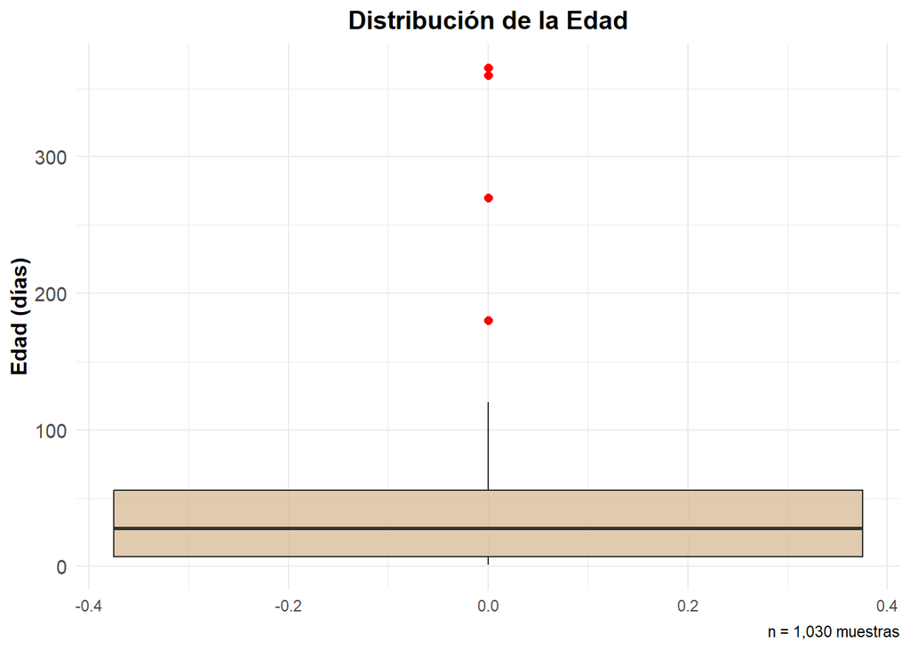

```r
ggplot(Concrete, aes(y = Age)) +
  geom_boxplot(fill = "tan", alpha = 0.7, outlier.color = "red", outlier.size = 2) +
  labs(
    title = "Distribución de la Edad",
    y = "Edad (días)",
    caption = "n = 1,030 muestras"
  ) +
  theme_minimal() +
  theme(
    plot.title = element_text(hjust = 0.5, face = "bold", size = 14),
    axis.text.y = element_text(size = 11),
    axis.title.y = element_text(face = "bold", size = 12)
  )
```

```r
Concrete %>%
  summarise(
    n = length(Age),
    media = mean(Age),
    ds = sd(Age),
    CV = (sd(Age) / mean(Age)) * 100,
    mediana = median(Age),
    minimo = min(Age),
    maximo = max(Age),
    Q1 = quantile(Age, 0.25),
    Q3 = quantile(Age, 0.75),
    IQR = IQR(Age)
  )
```

```
##      n    media       ds      CV mediana minimo maximo Q1 Q3 IQR
## 1 1030 45.66214 63.16991 138.342      28      1    365  7 56  49
```

## Analisis bivariado y coorelacion

```r
df <- read_excel("C:/Users/jacob/OneDrive/Escritorio/Datasets/Concrete_Data.xls")
View(df)

colnames(df)
```

```
## [1] "Cement (component 1)(kg in a m^3 mixture)"
## [2] "Blast Furnace Slag (component 2)(kg in a m^3 mixture)"
## [3] "Fly Ash (component 3)(kg in a m^3 mixture)"
## [4] "Water  (component 4)(kg in a m^3 mixture)"
## [5] "Superplasticizer (component 5)(kg in a m^3 mixture)"
## [6] "Coarse Aggregate  (component 6)(kg in a m^3 mixture)"
## [7] "Fine Aggregate (component 7)(kg in a m^3 mixture)"
## [8] "Age (day)"
## [9] "Concrete compressive strength(MPa, megapascals)"
```

```r
##Renombramos para practicidad.

names(df)[names(df) == "Concrete compressive strength(MPa, megapascals)"] <- "Resistencia_c"

names(df)[names(df) == "Cement (component 1)(kg in a m^3 mixture)"] <- "Cemento"

names(df)[names(df) == "Blast Furnace Slag (component 2)(kg in a m^3 mixture)"] <- "Residuos"

names(df)[names(df) == "Fly Ash (component 3)(kg in a m^3 mixture)"] <- "Cenizas"

names(df)[names(df) == "Water  (component 4)(kg in a m^3 mixture)"] <- "Agua"

names(df)[names(df) == "Superplasticizer (component 5)(kg in a m^3 mixture)" ] <- "Superplastificante"

names(df)[names(df) == "Coarse Aggregate  (component 6)(kg in a m^3 mixture)" ] <- "Grueso"

names(df)[names(df) == "Fine Aggregate (component 7)(kg in a m^3 mixture)" ] <- "Fino"

names(df)[names(df) == "Age (day)" ] <- "Dias"

colnames(df)
```

```
## [1] "Cemento"            "Residuos"           "Cenizas"
## [4] "Agua"               "Superplastificante" "Grueso"
## [7] "Fino"               "Dias"               "Resistencia_c"
```

# veamos la normalidad de nuestra variable objetivo

```r
ks.test(df$Resistencia_c, "pnorm", mean = mean(df$Resistencia_c), sd = sd(df$Resistencia_c))
```

```
##
##  Asymptotic one-sample Kolmogorov-Smirnov test
##
## data:  df$Resistencia_c
## D = 0.041303, p-value = 0.05954
## alternative hypothesis: two-sided
```

```r
print("Nuestra variable resistencia es normal.")
```

```
## [1] "Nuestra variable resistencia es normal."
```

## 1. RESISTENCIA VS CEMENTO———-

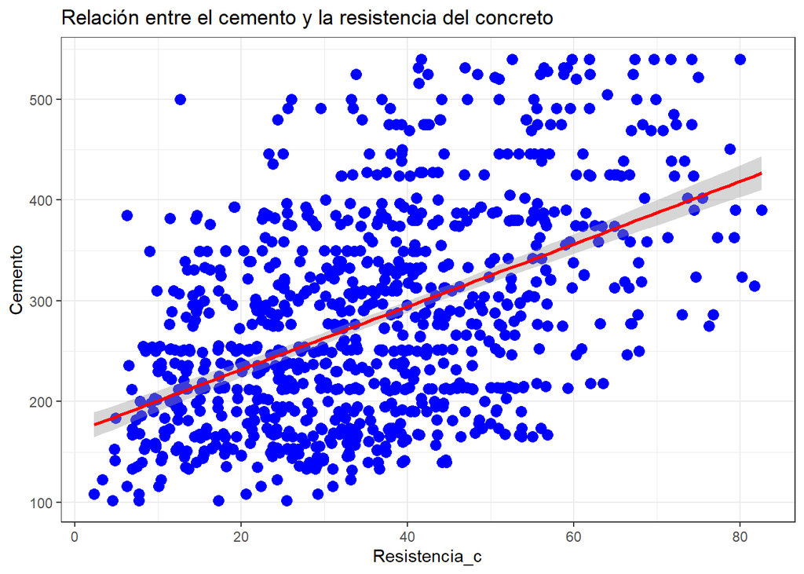

```r
#Hacemos el primer gráfico de dispersión, entre la resistencia y el cemento

df %>%
  ggplot(aes(x=Resistencia_c, y = Cemento)) +
  geom_point(color = "blue",size = 3) +
  geom_smooth(formula = 'y~x', method = "lm",se = TRUE,color="red") +
  labs(
    title = "Relación entre el cemento y la resistencia del concreto",
    x = "Resistencia_c",
    y = "Cemento"
  ) +
  theme_bw()
```

```r
ks.test(df$Cemento, "pnorm", mean = mean(df$Cemento), sd = sd(df$Cemento))
```

```
##
##  Asymptotic one-sample Kolmogorov-Smirnov test
##
## data:  df$Cemento
## D = 0.078553, p-value = 6.034e-06
## alternative hypothesis: two-sided
```

```r
print("La variable cemento no es normal. El pvalor<0.05. ")
```

```
## [1] "La variable cemento no es normal. El pvalor<0.05. "
```

```r
#como una de nuestras variables no es normal, debemos validar los supuestos de spearman



# 1️⃣ Verifica que las variables sean numéricas
is.numeric(df$Cemento)
```

```
## [1] TRUE
```

```r
is.numeric(df$Resistencia_c)
```

```
## [1] TRUE
```

```r
# 2️⃣ Revisa valores faltantes
sum(is.na(df$Cemento))
```

```
## [1] 0
```

```r
sum(is.na(df$Resistencia_c))
```

```
## [1] 0
```

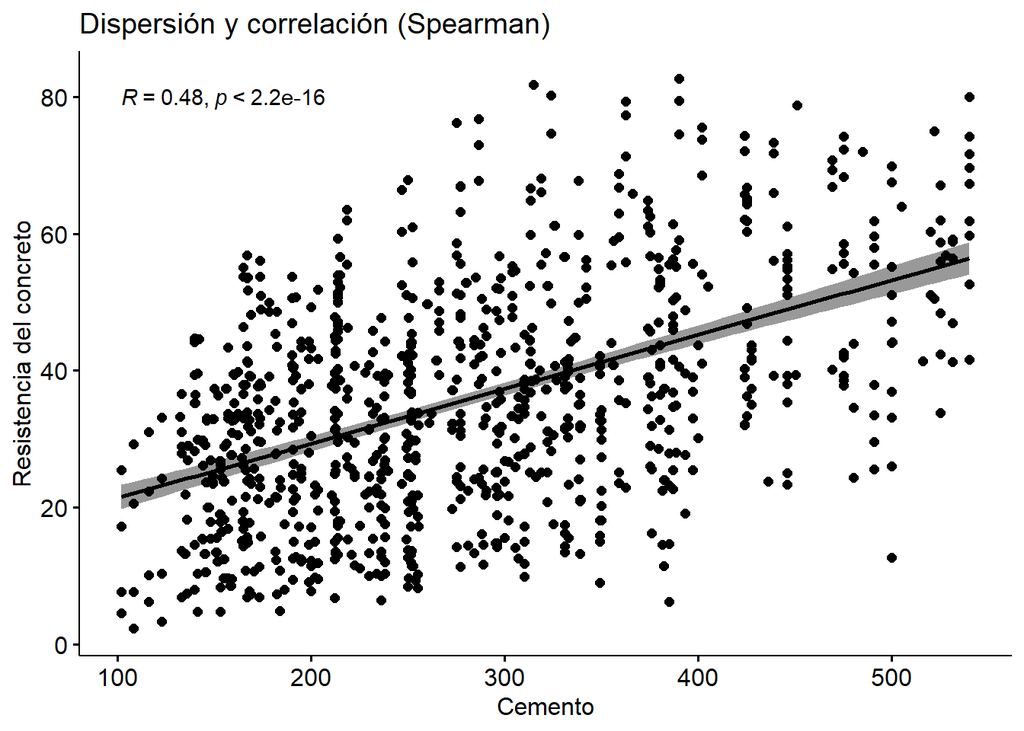

```r
# 3️⃣ Visualiza la relación
ggscatter(df, x = "Cemento", y = "Resistencia_c",
          add = "reg.line", conf.int = TRUE,
          cor.coef = TRUE, cor.method = "spearman",
          xlab = "Cemento", ylab = "Resistencia del concreto",
          title = "Dispersión y correlación (Spearman)")
```

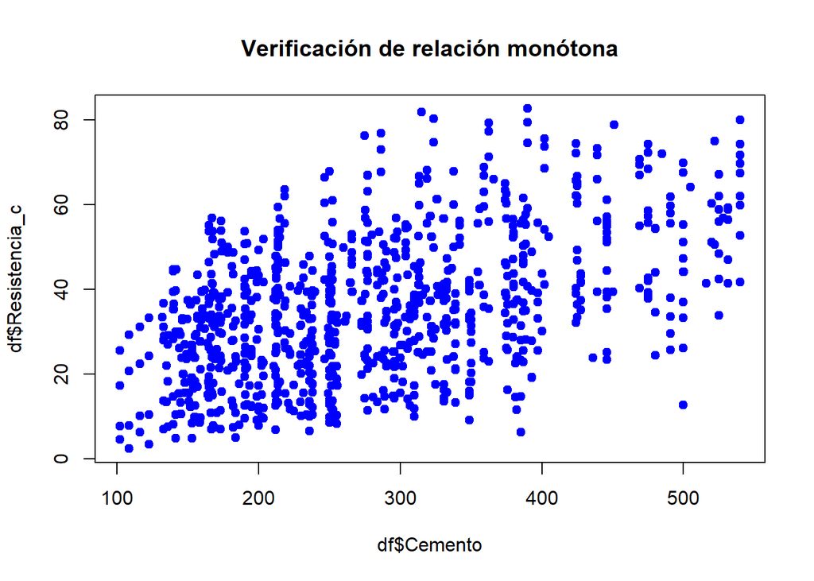

```r
# 4️⃣ Verifica la forma de la relación (monótona)
# Si la relación es creciente o decreciente, aunque no lineal, se puede usar Spearman
plot(df$Cemento, df$Resistencia_c, pch = 19, col = "blue",
     main = "Verificación de relación monótona")
```

```r
# 5️⃣ Ejecuta la prueba de correlación de Spearman
resultado <- cor.test(df$Cemento, df$Resistencia_c, method = "spearman", exact=FALSE)
resultado
```

```
##
##  Spearman's rank correlation rho
##
## data:  df$Cemento and df$Resistencia_c
## S = 95139797, p-value < 2.2e-16
## alternative hypothesis: true rho is not equal to 0
## sample estimates:
##       rho
## 0.4776012
```

Planteamos las hipótesis:

$$H_0: \rho_S = 0 \quad \text{(no hay relación monótona)}$$

$$H_1: \rho_S \neq 0 \quad \text{(existe relación monótona)}$$

Veamos:

```r
n <- nrow(df)
gl = n-2
p = resultado$estimate[[1]]
t_critico = p*sqrt(gl/1-p^2)
alpha = 0.05
t_tab = qt(1-alpha/2,df=gl)
t_critico
```

```
## [1] 15.31136
```

```r
t_tab
```

```
## [1] 1.962274
```

rechazamos h0 :nuestro t critico mayor que el t en tabla por lo que con una confianza del 95% la correlacion es significativa